# Animal Models

Thiago de Paula Oliveira, Ivan Pocrnic, Gregor Gorjanc

10/05/2022

All our algorithms and analysis was built using a stable version 4.3.0 of JAGS, stable version 0.10.1 of NIMBLE, and `R` version 3.6.3. We are also using the packages `rjags` (Denwood 2016) and `nimble` (Valpine et al. 2020), to build models, `coda` (Plummer et al. 2009) and `MCMCvis` (Youngflesh 2018) to extract summary information from MCMC output; `AlphaSimR` (Gaynor, Gorjanc, and Hickey 2020) to make animal breeding programme simulation; `MatrixModels`(Bates and Maechler 2015); and `pedigreemm`(Bates and Vazquez 2014); `ggplot2` (Wickham 2016), `patchwork` (Pedersen 2020), and `ggrepel` (Slowikowski 2020) to prepare graphical outputs; `dplyr` (Wickham et al. 2020), `knitr` (Xie 2020), `kableExtra`(Zhu 2020), and `formattable` (Ren and Russell 2016) for general purposes.

# 1 Brief description of animal model

Animal models have been widely used to investigate the impact of genetic and environmental factors on various phenotypic traits. To analyze the data obtained from such experiments, mixed-effects models are commonly employed. These models account for both fixed and random effects, with the phenotype values being a function of both.

While mixed-effects models have been used for several decades in various research fields, they have a specific significance when applied in genetics research. Random effects and their associated variance components play a crucial role in understanding the genetic factors contributing to a phenotype. However, these concepts can be complex and challenging to interpret. Therefore, it is essential to present them in a simple and easy-to-understand manner.

To illustrate this, let us consider a hypothetical experiment where we measure the response variable (phenotype) $y_i$ on the $i$th individual. Some individuals have one or both parents unknown, while others belong to a group factor with two levels (1 or 2), as shown in the following database:

Table 1.1: Example data set for animal model

| individual | father | mother | phenotype | group |
| --- | --- | --- | --- | --- |
| 1 | NA | NA | NA | NA |
| 2 | NA | NA | 105 | 1 |
| 3 | 2 | 1 | 98 | 1 |
| 4 | 2 | NA | 101 | 2 |
| 5 | 4 | 3 | 106 | 2 |
| 6 | 2 | 3 | 93 | 2 |
| 7 | 5 | 6 | NA | NA |
| 8 | NA | NA | NA | NA |
| 9 | 7 | 8 | 109 | 1 |

To capture the relationship between $y_i$ and covariates, the most straightforward approach is to use a model:

$$\begin{align}
\begin{array}{c}
y_{ij} = b_{j} + a_{i} + e_{ij}, \\
b_{j} = m + Gr_{j}, \quad a_{i} \sim \mbox{N}\left(0, \sigma_{a}^{2}\right), \quad e_{ij} \sim \mbox{N}\left(0,\sigma^2_{e}\right).
\end{array}
\label{eq:basic_model}
\end{align}$$

The model for analyzing the relationship between the phenotype values $y_{ij}$ of individual $i$ from group $j$, can be represented as follows: $b_{j}$ is the mean value for group $j$, $a_{i}$ is the additive genetic value of individual $i$ (commonly referred to as breeding value), $m$ is the overall mean, $Gr_j$ is the effect of the $j$th group, and $e_{ij}$ represents the experimental error term.

This model can be further expanded to account for more complex experiments. Using matrix notation, it can be generalized as:

$$\begin{eqnarray}
\mathbf{y} & = & \mathbf{X}\mathbf{b}+\mathbf{Z}\mathbf{a}+\mathbf{e},\label{eq:animal_model}
\end{eqnarray}$$

In the above model, the design matrices $\mathbf{X}$ and $\mathbf{Z}$ establish the link between the unknown parameters $\mathbf{b}$ and predicted values at the population level $\mathbf{a}$ with the phenotypic values $\mathbf{y}$.

Under the standard assumption of phenotypes following a normal (Gaussian) distribution, $\mathbf{e}|\sigma_{e}^{2} \sim \mbox{N}\left(\mathbf{0},\sigma_{e}^{2}\mathbf{I}\right)$, $\mathbf{y}|\mathbf{a} \sim \mbox{N}\left(\mathbf{X}\mathbf{b}+\mathbf{Z}\mathbf{a}, \sigma_{e}^{2}\mathbf{\mathbf{I}}\right)$, and $\mathbf{y} \sim \mbox{N}\left(\mathbf{X}\mathbf{b}, \mathbf{Z}\mathbf{G}\mathbf{Z}^{T}+\sigma_{e}^{2}\mathbf{\mathbf{I}}\right)$, where $\mathbf{G}$ is the general variance-covariance matrix for $\mathbf{a}$.

Assuming $\mathbf{G} = \sigma_{a}^{2}\mathbf{A}$, where $\mathbf{A}$ is a numerator relationship matrix (NRM) used to account for the additive genetic covariance between records of related animals and $\sigma_{a}^{2}$ is the additive genetic variance, we get $\mathbf{a}|\mathbf{A},\sigma_{a}^{2} \sim \mbox{N}\left(\mathbf{0},\mathbf{A}\sigma_{a}^{2}\right)$.

Additionally, we can decompose the matrix $\mathbf{A}$ as $\mathbf{T}\mathbf{W}\mathbf{T}^{T}$, where $\mathbf{T}$ is a dense unit lower triangular matrix that describes the flow (trace) of genes in the pedigree, and $\mathbf{W}$ is a diagonal matrix with values that depend on the knowledge of parents and parent inbreeding coefficients.

Before we begin the specification of this model in `R`, let us check how the design matrices $\mathbf{X}$ and $\mathbf{Z}$, and matrices $\mathbf{A}$, $\mathbf{T}$, and $\mathbf{W}$ should be specified based on our `example`:

- Matrix $\mathbf{X}$ associated with fixed effects:

```r
(X <- model.Matrix(~ group, data=example))
```

```
## "ddenseModelMatrix": 6 x 2 Matrix of class "dgeMatrix"
##   (Intercept) group2
## 2           1      0
## 3           1      0
## 4           1      1
## 5           1      1
## 6           1      1
## 9           1      0
## @ assign:  0 1
## @ contrasts:
## $group
## [1] "contr.treatment"
```

- Matrix $\mathbf{Z}$ associated with random effects:

```r
Ind <- as.factor(example$individual)
(Z <- model.Matrix(~ Ind - 1, data = example, sparse=TRUE))
```

```
## "dsparseModelMatrix": 9 x 9 sparse Matrix of class "dgCMatrix"
##   Ind1 Ind2 Ind3 Ind4 Ind5 Ind6 Ind7 Ind8 Ind9
## 1    1    .    .    .    .    .    .    .    .
## 2    .    1    .    .    .    .    .    .    .
## 3    .    .    1    .    .    .    .    .    .
## 4    .    .    .    1    .    .    .    .    .
## 5    .    .    .    .    1    .    .    .    .
## 6    .    .    .    .    .    1    .    .    .
## 7    .    .    .    .    .    .    1    .    .
## 8    .    .    .    .    .    .    .    1    .
## 9    .    .    .    .    .    .    .    .    1
## @ assign:  1 1 1 1 1 1 1 1 1
## @ contrasts:
## $Ind
## [1] "contr.treatment"
```

- Matrix $\mathbf{A}$:

```r
MASS::fractions(as.matrix(A))
```

```
##       [,1]  [,2]  [,3]  [,4]  [,5]  [,6]  [,7]  [,8]  [,9]
##  [1,]     1     0   1/2     0   1/4   1/4   1/4     0   1/8
##  [2,]     0     1   1/2   1/2   1/2   3/4   5/8     0  5/16
##  [3,]   1/2   1/2     1   1/4   5/8   3/4 11/16     0 11/32
##  [4,]     0   1/2   1/4     1   5/8   3/8   1/2     0   1/4
##  [5,]   1/4   1/2   5/8   5/8   9/8  9/16 27/32     0 27/64
##  [6,]   1/4   3/4   3/4   3/8  9/16   5/4 29/32     0 29/64
##  [7,]   1/4   5/8 11/16   1/2 27/32 29/32 41/32     0 41/64
##  [8,]     0     0     0     0     0     0     0     1   1/2
##  [9,]   1/8  5/16 11/32   1/4 27/64 29/64 41/64   1/2     1
```

- Matrix $\mathbf{T}$ (lower triangular matrix):

```r
Tm
```

```
## 9 x 9 sparse Matrix of class "dtCMatrix"
##           1      2    3     4    5    6   7   8 9
##  [1,] 1.000 .      .    .     .    .    .   .   .
##  [2,] .     1.0000 .    .     .    .    .   .   .
##  [3,] 0.500 0.5000 1.00 .     .    .    .   .   .
##  [4,] .     0.5000 .    1.000 .    .    .   .   .
##  [5,] 0.250 0.5000 0.50 0.500 1.00 .    .   .   .
##  [6,] 0.250 0.7500 0.50 .     .    1.00 .   .   .
##  [7,] 0.250 0.6250 0.50 0.250 0.50 0.50 1.0 .   .
##  [8,] .     .      .    .     .    .    .   1.0 .
##  [9,] 0.125 0.3125 0.25 0.125 0.25 0.25 0.5 0.5 1
```

- $\mathbf{W}$ (the variance and covariance matrix for Mendelian sampling):

```r
(MASS::fractions(as.matrix(Wm)))
```

```
##       [,1]   [,2]   [,3]   [,4]   [,5]   [,6]   [,7]   [,8]   [,9]
##  [1,]      1      0      0      0      0      0      0      0      0
##  [2,]      0      1      0      0      0      0      0      0      0
##  [3,]      0      0    1/2      0      0      0      0      0      0
##  [4,]      0      0      0    3/4      0      0      0      0      0
##  [5,]      0      0      0      0    1/2      0      0      0      0
##  [6,]      0      0      0      0      0    1/2      0      0      0
##  [7,]      0      0      0      0      0      0  13/32      0      0
##  [8,]      0      0      0      0      0      0      0      1      0
##  [9,]      0      0      0      0      0      0      0      0 55/128
```

- Vector of the diagonal for matrix $\mathbf{W}^{-1}$:

```r
diag(WInv <- Diagonal(x=1/Dmat(pedigree1)))
```

```
## [1] 1.000000 1.000000 2.000000 1.333333 2.000000 2.000000 2.461538 1.000000
## [9] 2.327273
```

# 2 BUGS language and JAGS implementation

The animal model code presented here is a direct representation of the directed acyclic graph (DAG) using the BUGS language. The code shown below is similar to the one presented by Waldmann (2009a), but is more concise and generalizable.

```r
# Animal model in BUGS language
AnimalModelBUGSVar <- function()
{
  ## Priors - precision parameters
  tau2e ~ dgamma(0.001, 0.001)
  tau2a ~ dgamma(0.001, 0.001)
  sigma2e <- pow(tau2e, -1)
  sigma2a <- pow(tau2a, -1)

  ## Additive genetic values
  for(k in 1:nI) {
    a[id[k]] ~ dnorm(pa[id[k]], Xtau2a[id[k]])
    pa[id[k]] <- 0.5 * (a[fid[k]] + a[mid[k]])
    Xtau2a[id[k]] <- winv[id[k]] * tau2a
  }
  a[nU] <- 0 # NULL (zero) holder

  ## Fixed Effects
  for(j in 1:nB) { b[j] ~ dnorm(0, 1.0E-6) }

  ## Phenotypes
  for(i in 1:nY) {
    y[i] ~ dnorm(mu[i], tau2e)
    mu[i] <- inprod(x[i, ], b[]) + a[idy[i]]
  }
}
```

Waldmanns’ proposal treats founders and non-founders separately, assumes that phenotypic data is available only for non-founders, neglects the inbreeding when calculating the coefficients of within-family segregation variance is not easy to extend. There are no such limitations in `AnimalModelBUGSVar`.

Required data for the proposed implementation is symbolically shown bellow:

```r
tmp <- AnimalModelBUGSData(ped=example, intercept = FALSE)

# Pedigree 'Plate'
list(nI = tmp$nI, id = tmp$id, fid = tmp$fid, mid = tmp$mid,
     winv = tmp$winv, nU = tmp$nU)
```

```
## $nI
## [1] 9
##
## $id
## [1] 1 2 3 4 5 6 7 8 9
##
## $fid
## [1] 10 10  2  2  4  2  5 10  7
##
## $mid
## [1] 10 10  1 10  3  3  6 10  8
##
## $winv
## [1] 1.000000 1.000000 2.000000 1.333333 2.000000 2.000000 2.461538 1.000000
## [9] 2.327273
##
## $nU
## [1] 10
```

```r
# Phenotype 'plate'
list(nY = tmp$nY, idy = tmp$idy, y = tmp$y, nB = tmp$nB, x = tmp$x)
```

```
## $nY
## [1] 6
##
## $idy
## [1] 2 3 4 5 6 9
##
## $y
## [1] 105  98 101 106  93 109
##
## $nB
## [1] 2
##
## $x
##   group1 group2
## 1      1      0
## 2      1      0
## 3      0      1
## 4      0      1
## 5      0      1
## 6      1      0
## attr(,"assign")
## [1] 1 1
## attr(,"contrasts")
## attr(,"contrasts")$group
## [1] "contr.treatment"
```

```r
# Variance
sigma2a <- 1/3
sigma2e <- 1

# Precision = 1 / variance
tmp$tau2a <- 1 / sigma2a
tmp$tau2e <- 1 / sigma2e
```

The length of variables may vary, but this can be accommodated using the list structure described in the JAGS manual. To use the `AnimalModelBUGSVar` package, users must provide pedigree information in the form of three integer identification vectors, namely `id` for individual identification, `fid` for father identification, and `mid` for mother identification. Additionally, a vector `winv` with the coefficients of within-family segregation variance is required. The length of these vectors is $nI\times1$, where $nI$ is the number of all individuals in the pedigree.

It is not necessary for the identifications to range between $1$ and $nI$, although this is commonly done. In fact, even character names can be used for identifications in JAGS. However, several other programs rely on the integer coding of pedigree members.

All unknown parents must be presented with the identification number $nU$, commonly $nU=nI+1$. This corresponds to an additional dummy node (`a[nU]`) in the DAG. The addition of a dummy node enables the use of the same code for founders and non-founders and is mandatory because BUGS/JAGS does not allow ‘zero indexing’ (e.g. `a[0]`) as has been suggested by Damgaard (2007a). Variables regarding the phenotypes are:

- the number of phenotypic records (`nY`), individual identifications (`idy`) which link phenotypes and pedigree as sketched by $\mathbf{Z}_{i,k}$ arc.
- phenotypic values (`y`)
- model predictor(s) (`x`), which can be either a factor or covariate, and
- the number of fixed effects (`nB`).

When working with JAGS, it is not necessary to sort the data (phenotypes, pedigree, and identifications) in chronological or any other order. However, other programs that work with pedigree data may require the data to be ordered in a specific way.

Records with missing phenotypes are excluded, except for the pedigree part. However, JAGS offers a notable feature when it comes to missing values. If the phenotype is missing but other variables are not, such a record can be added to the data (setting the phenotype to `NA`), and JAGS will automatically impute a randomly generated value given the specified model. This feature can be used to create simulated data according to an animal model (e.g. Van Vleck (1994)).

Since JAGS does not allow the specification of improper distributions, the developers suggest using a conditionally conjugate gamma distribution for $\tau^{2}$ (`tau2`) with small values for both parameters, i.e., $p\left(\tau^{2}\right)\sim Gamma\left(0.001,0.001\right)$. This is equivalent to $p\left(\sigma^{2}\right)\sim Inverse-Gamma\left(0.001,0.001\right)$. Waldmann (2009a) used uniform priors for standard deviations ($\sigma_{a}$ and $\sigma_{e}$) following the suggestion of Gelman (2006), who demonstrated that this prior appears to be less informative for models with a small number of groups (individuals) or a small between-group variance. However, this scenario should be of concern for quantitative geneticists analyzing traits with small genetic variability.

Variance priors in AnimalModelBUGSVar use a conditionally conjugate gamma distribution, enabling BUGS/JAGS to use Gibbs sampling instead of other, more time-consuming algorithms. However, this does not imply that the gamma prior for precisions should be preferred over the uniform prior for standard deviations. Users are encouraged to perform sensitivity analyses with different priors and decide whether priors affect their conclusions. Using the approach described here, JAGS users can easily conduct such analyses by changing a line or two in AnimalModelBUGSVar.

# 3 Animal models accounting or not for inbreeding

## 3.1 Example 2: Animal model ignoring inbreeding

```r
# General JAGs definitions
#-----------------------------------------------------------------------
# Initialization
#-----------------------------------------------------------------------
initfunction <- function(chain) {
  nI <- 9
  nB <- 2
  nc <- 3
  stopifnot(chain %in% 1:nc)
  a <- b <- list()
  for(i in 1:nc){
    a[[i]] <- c(rnorm(nI,0,2),NA)
    b[[i]] <- rnorm(nB,100,10)
  }
  .RNG.name <- rep("base::Super-Duper", 3)[chain]
  .RNG.seed = seq(1,3,1)[chain]
  return(list(a = a[[chain]], b = b[[chain]],
              .RNG.seed = .RNG.seed, .RNG.name = .RNG.name))
}

## runJags
nChains <- 3
nBurninSteps <- 30000
nThinSteps <- 15
nUseSteps <- 60000

# Number of fitted models to calculating computing cost
nt <- 50
```

```r
#-----------------------------------------------------------------------
## For repeatability model
#-----------------------------------------------------------------------
## Hyperparameters - variance of additive genetic values and variance of
## residuals
sigma2a <- 1/3
sigma2e <- 1

# Heritability
(h2 <- sigma2a / (sigma2a + sigma2e)) ## 0.25
```

```
## [1] 0.25
```

```r
#=======================================================================
# Animal Model ignoring inbreeding
#=======================================================================
## Prepair data - ignoring inbreeding
tmp <- AnimalModelBUGSData(ped=example,  inbreeding = FALSE,
                            intercept = FALSE)

## Set precisions
tmp$tau2a <- 1 / sigma2a
tmp$tau2e <- 1 / sigma2e
tmp
```

```
## $nI
## [1] 9
##
## $nY
## [1] 6
##
## $y
## [1] 105  98 101 106  93 109
##
## $nU
## [1] 10
##
## $id
## [1] 1 2 3 4 5 6 7 8 9
##
## $fid
## [1] 10 10  2  2  4  2  5 10  7
##
## $mid
## [1] 10 10  1 10  3  3  6 10  8
##
## $winv
## [1] 1.000000 1.000000 2.000000 1.333333 2.000000 2.000000 2.000000 1.000000
## [9] 2.000000
##
## $idy
## [1] 2 3 4 5 6 9
##
## $x
##   group1 group2
## 1      1      0
## 2      1      0
## 3      0      1
## 4      0      1
## 5      0      1
## 6      1      0
## attr(,"assign")
## [1] 1 1
## attr(,"contrasts")
## attr(,"contrasts")$group
## [1] "contr.treatment"
##
##
## $nB
## [1] 2
##
## $tau2a
## [1] 3
##
## $tau2e
## [1] 1
```

### 3.1.1 JAGs model

```r
AnimalModelBUGS <- function()
{
  ## Additive genetic values
  for(k in 1:nI) {
    a[id[k]] ~ dnorm(pa[id[k]], Xtau2a[id[k]])
    pa[id[k]] <- 0.5 * (a[fid[k]] + a[mid[k]])
    Xtau2a[id[k]] <- winv[id[k]] * tau2a
  }
  a[nU] <- 0 # NULL (zero) holder

  ## Location priors
  for(j in 1:nB) { b[j] ~ dnorm(0, 1.0E-6) }

  ## Phenotypes
  for(i in 1:nY) {
    y[i] ~ dnorm(mu[i], tau2e)
    mu[i] <- inprod(x[i, ], b[]) + a[idy[i]]
  }
}
```

**Some comments:**

- `x[i, ]` is the $i$th line of matrix $\mathbf{X}$;
- `b[]` is the vector of fixed effects;
- `a[id[k]]` is the additive genetic ($a_{i} \sim \mbox{N}\left(0, \sigma_{a}^{2}\right)$);
- `pa[id[k]]` is the expected value based on parents additive genetic ($1/2\left(a_{father(i)}+ a_{mother(i)}\right)$);
- `winv[id[k]]` is the within family segregation variance coefficients;
- `tau2a` is the precision parameter, which is the reciprocal of the genetic variance ($\sigma^2_{a}=1/\tau^2_a$);
- `tau2e` is the precision parameter for the experimental error;

```r
## Writing the JAGS model
filename <- "model.txt"
writeJags(model = AnimalModelBUGS, filename = filename)
#-----------------------------------------------------------------------
# Jags
#-----------------------------------------------------------------------
## runJags
jags_params <- c("a", "b")
runJagsOut <- run.jags(method = "parallel",
                       model = filename,
                       monitor = jags_params,
                       data = tmp,
                       n.chains = nChains,
                       burnin = nBurninSteps,
                       sample = ceiling(nUseSteps/nChains),
                       thin = nThinSteps,
                       summarise = FALSE,
                       plots = FALSE,
                       inits = initfunction)
```

```
## Calling 3 simulations using the parallel method...
## Following the progress of chain 1 (the program will wait for all chains
## to finish before continuing):
## Welcome to JAGS 4.3.0 on Tue May  2 07:12:20 2023
## JAGS is free software and comes with ABSOLUTELY NO WARRANTY
## Loading module: basemod: ok
## Loading module: bugs: ok
## . . Reading data file data.txt
## . Compiling model graph
## . Reading parameter file inits1.txt
## . Initializing model
## . Adaptation skipped: model is not in adaptive mode.
## . Updating 30000
## -------------------------------------------------| 30000
## ************************************************** 100%
## . . . Updating 300000
## -------------------------------------------------| 300000
## ************************************************** 100%
## . . . . Updating 0
## . Deleting model
## .
## All chains have finished
## Note: the model did not require adaptation
## Simulation complete.  Reading coda files...
## Coda files loaded successfully
## Finished running the simulation
```

```r
# coda samples - MCMC
coda_samples <- as.mcmc.list(runJagsOut)

# parameter estimates
estimatesNoInbreeding <- MCMCsummary(coda_samples, round = 4)
estimatesNoInbreeding
```

|  | mean | sd | 2.5% | 50% | 97.5% | Rhat | n.eff |
| --- | --- | --- | --- | --- | --- | --- | --- |
| a[1] | -0.6997 | 0.5617 | -1.7930 | -0.7008 | 0.4010 | 1 | 59848 |
| a[2] | -0.4985 | 0.5520 | -1.5762 | -0.4998 | 0.5742 | 1 | 53338 |
| a[3] | -1.2976 | 0.5485 | -2.3792 | -1.2956 | -0.2296 | 1 | 52336 |
| a[4] | 0.5880 | 0.5575 | -0.5001 | 0.5892 | 1.6777 | 1 | 54407 |
| a[5] | 0.6708 | 0.5963 | -0.4964 | 0.6718 | 1.8348 | 1 | 53724 |
| a[6] | -1.6537 | 0.6126 | -2.8516 | -1.6534 | -0.4549 | 1 | 51870 |
| a[7] | -0.1737 | 0.6698 | -1.4987 | -0.1718 | 1.1335 | 1 | 51793 |
| a[8] | 0.6372 | 0.5656 | -0.4615 | 0.6379 | 1.7476 | 1 | 59138 |
| a[9] | 0.8675 | 0.5729 | -0.2557 | 0.8664 | 1.9849 | 1 | 54011 |
| a[10] | 0.0000 | 0.0000 | 0.0000 | 0.0000 | 0.0000 | NaN | 0 |

[output cut: 2 more lines]

## 3.2 Example 2: Animal model accounting for inbreeding

```r
## Prepair data
tmp <- AnimalModelBUGSData(ped=example, intercept = FALSE)

## Set precisions
tmp$tau2a <- 1 / sigma2a
tmp$tau2e <- 1 / sigma2e

tmp
```

```
## $nI
## [1] 9
##
## $nY
## [1] 6
##
## $y
## [1] 105  98 101 106  93 109
##
## $nU
## [1] 10
##
## $id
## [1] 1 2 3 4 5 6 7 8 9
##
## $fid
## [1] 10 10  2  2  4  2  5 10  7
##
## $mid
## [1] 10 10  1 10  3  3  6 10  8
##
## $winv
## [1] 1.000000 1.000000 2.000000 1.333333 2.000000 2.000000 2.461538 1.000000
## [9] 2.327273
##
## $idy
## [1] 2 3 4 5 6 9
##
## $x
##   group1 group2
## 1      1      0
## 2      1      0
## 3      0      1
## 4      0      1
## 5      0      1
## 6      1      0
## attr(,"assign")
## [1] 1 1
## attr(,"contrasts")
## attr(,"contrasts")$group
## [1] "contr.treatment"
##
##
## $nB
## [1] 2
##
## $tau2a
## [1] 3
##
## $tau2e
## [1] 1
```

```r
#=======================================================================
##  Animal model known variance
#=======================================================================
AnimalModelBUGS <- function()
{
  ## Additive genetic values
  for(k in 1:nI) {
    a[id[k]] ~ dnorm(pa[id[k]], Xtau2a[id[k]])
    pa[id[k]] <- 0.5 * (a[fid[k]] + a[mid[k]])
    Xtau2a[id[k]] <- winv[id[k]] * tau2a
  }
  a[nU] <- 0 # NULL (zero) holder

  ## Location priors
  for(j in 1:nB) { b[j] ~ dnorm(0, 1.0E-6) }

  ## Phenotypes
  for(i in 1:nY) {
    y[i] ~ dnorm(mu[i], tau2e)
    mu[i] <- inprod(x[i, ], b[]) + a[idy[i]]
  }
}
```

### 3.2.1 JAGs model

```r
## Structuring the dataset
tmp <- AnimalModelBUGSData(ped=example, intercept = FALSE)

## Set precisions
tmp$tau2a <- 1 / sigma2a
tmp$tau2e <- 1 / sigma2e

print(tmp)

## Writing the JAGS model
filename <- "model.txt"
writeJags(model = AnimalModelBUGS, filename = filename)
#=======================================================================
# Jags
#=======================================================================
jags_params <- c("a", "b")
runJagsOut <- run.jags(method = "parallel",
                       model = filename,
                       monitor = jags_params,
                       data = tmp,
                       n.chains = nChains,
                       burnin = nBurninSteps,
                       sample = ceiling(nUseSteps/nChains),
                       thin = nThinSteps,
                       summarise = FALSE,
                       plots = FALSE,
                        inits = initfunction)
# coda samples - MCMC
coda_samples <- as.mcmc.list(runJagsOut)
```

### 3.2.2 Parameter estimates

```r
# Estimates
estimatesInbreeding <- MCMCsummary(coda_samples, round = 4)
estimatesInbreeding
```

|  | mean | sd | 2.5% | 50% | 97.5% | Rhat | n.eff |
| --- | --- | --- | --- | --- | --- | --- | --- |
| a[1] | -0.7023 | 0.5617 | -1.7956 | -0.7032 | 0.3998 | 1 | 59331 |
| a[2] | -0.5076 | 0.5519 | -1.5857 | -0.5089 | 0.5650 | 1 | 52646 |
| a[3] | -1.3061 | 0.5483 | -2.3851 | -1.3054 | -0.2361 | 1 | 51222 |
| a[4] | 0.5851 | 0.5575 | -0.5037 | 0.5855 | 1.6737 | 1 | 53887 |
| a[5] | 0.6677 | 0.5962 | -0.4991 | 0.6674 | 1.8330 | 1 | 52707 |
| a[6] | -1.6595 | 0.6126 | -2.8584 | -1.6589 | -0.4621 | 1 | 50927 |
| a[7] | -0.2333 | 0.6464 | -1.5120 | -0.2306 | 1.0225 | 1 | 50298 |
| a[8] | 0.6478 | 0.5655 | -0.4515 | 0.6474 | 1.7580 | 1 | 59139 |
| a[9] | 0.7627 | 0.5517 | -0.3217 | 0.7613 | 1.8378 | 1 | 53266 |
| a[10] | 0.0000 | 0.0000 | 0.0000 | 0.0000 | 0.0000 | NaN | 0 |

[output cut: 2 more lines]

## 3.3 Camparing both animal models (with and without inbreeding)

```r
#-----------------------------------------------------------------------

#-----------------------------------------------------------------------
data_comp <- data.frame(NoInb = estimatesNoInbreeding[c(1:9), 1],
                        Inb = estimatesInbreeding[c(1:9), 1],
                        Animal = gl(n = 9,  k = 1,
                                    labels = paste0("Animal ", 1:9)))
```

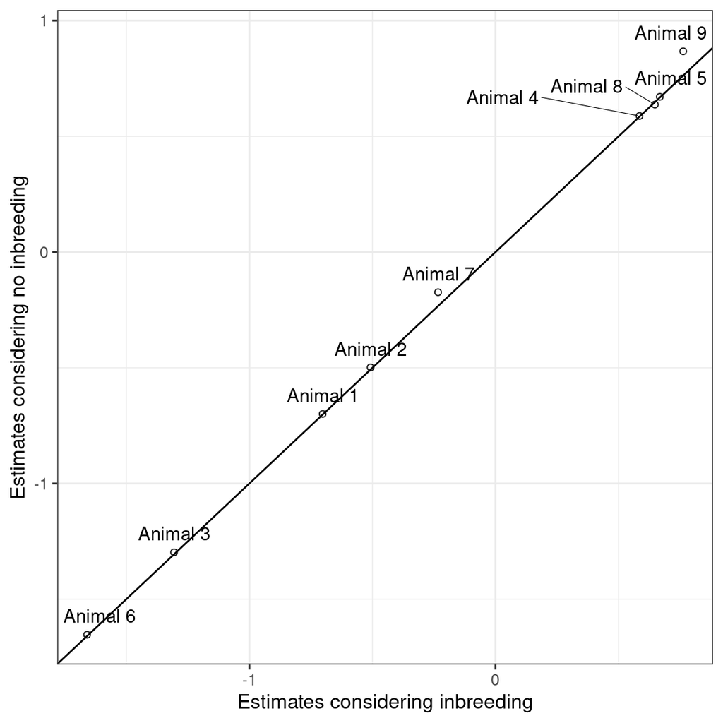

Figure 3.1: A

```r
data_comp %>%
  ggplot(aes(y = NoInb,  x = Inb,  label = Animal)) +
  geom_point(shape = 1,  alpha = 0.9) +
  geom_abline(intercept = 0,  slope = 1) +
  geom_text_repel(
    nudge_y      = 0.05,
    direction    = "x",
    vjust        = 0,
    segment.size = 0.2) +
  ylab("Estimates considering no inbreeding") +
  xlab("Estimates considering inbreeding") +
  theme_bw(base_size = 12)
```

```r
data_diff <- data.frame(
  Parameter = rownames(estimatesInbreeding)[c(1:9, 11:12)],
  Difference = estimatesNoInbreeding[c(1:9,  11, 12), 1] -
               estimatesInbreeding[c(1:9,  11, 12), 1],
  Ratio = estimatesNoInbreeding[c(1:9,  11, 12), 1]/
          estimatesInbreeding[c(1:9,  11, 12), 1])
```

Table 3.1: Difference and ratio between parameter estimates

| Parameter | Difference | Ratio |
| --- | --- | --- |
| a[1] | 0.0026 | 0.9963 |
| a[2] | 0.0091 | 0.9821 |
| a[3] | 0.0085 | 0.9935 |
| a[4] | 0.0029 | 1.0050 |
| a[5] | 0.0031 | 1.0046 |
| a[6] | 0.0058 | 0.9965 |
| a[7] | 0.0596 | 0.7445 |
| a[8] | -0.0106 | 0.9836 |
| a[9] | 0.1048 | 1.1374 |
| b[1] | -0.0408 | 0.9996 |
| b[2] | -0.0040 | 1.0000 |

Mehrabani-Yeganeh, Gipson, and Schaeffer (2001) simulated populations and selected animals based on the computed additive genetic values, with and without accounting for inbreeding. They concluded that missing inbreeding did not affect animals’ ranking and, consequently, response to selection, even with high inbreeding levels. However, neglecting inbreeding results in underestimating additive genetic variance in the base population due to overestimated family segregation coefficients in non-base individuals.

Furthermore, when inbreeding is accounted for, the animal model, coupled with McMC methods, can infer the change of additive genetic variance over generations due to the Bulmer effect (Sorensen, Fernando, and Gianola 2001). However, the applicability of this method for evolutionary studies still needs to be assessed. Therefore, it is advisable to account for inbreeding if possible.